# Final_R_Reference

Min Hein Htike

12/14/2021

## Intro

This is a set of R examples for my personal reference beyond this course.

## Loading Data and Packages

1. Install the here package.
2. Download and read data files into R.
3. Perform an exploratory data analysis.

To install here we can just type:

```
install.packages("here")
```

to read data,

```
here()
read.csv()
```

For examples: to load the **2021 ginkgo lead data** which is stored in the *env_data/data/ginkgo_data_2021.csv*, the following code should be used.

```
require(here)
read.csv(here("data", "ginkgo_data_2021.csv"))
```

To load the packages which we want to load, we can just use `require()` and `library()`

```
require(palmerpenguins)
```

## Data Structures:

Required Functions: `c()` `length()` `matrix()` `data.frame()`

### Length description: `length()`

The `length()` function allows you to get or set the length of vectors and factors. Getting the length is useful for counting the number of entries in a column of a **dataframe**, which might help you figure out the number of samples in your data. *Example of counting the number of entries in a column of a dataframe*

```r
require(here)
ginkgo <- read.csv(here("data", "ginkgo_data_2021.csv"))
length(ginkgo$max_width)
```

```
## [1] 756
```

The `length()` function determines how many elements are in a vector.

### Vector `c()` example

```r
num_vec  = c(1, 4, 8, 9, 13)
```

### The length function will give an output of the number of values in our example vector

```r
length(num_vec)
```

```
## [1] 5
```

### matrix()

A Matrix is created using the `matrix()` function. **Syntax** The basic syntax for creating a matrix in R is −

```
matrix(data, nrow, ncol, byrow, dimnames)
```

Following is the description of the parameters used −

- **data** is the input vector which becomes the data elements of the matrix.
- **nrow** is the number of rows to be created.
- **ncol** is the number of columns to be created.
- **byrow** is a logical clue. If TRUE then the input vector elements are arranged by row.
- **dimname** is the names assigned to the rows and columns.

```r
test_matrix <- matrix(num_vec, nrow= 5, ncol= 3)
test_matrix
```

```
##      [,1] [,2] [,3]
## [1,]    1    1    1
## [2,]    4    4    4
## [3,]    8    8    8
## [4,]    9    9    9
## [5,]   13   13   13
```

```r
test_matrix_2 <- matrix(num_vec, byrow= TRUE, nrow= 1)
test_matrix_2
```

```
##      [,1] [,2] [,3] [,4] [,5]
## [1,]    1    4    8    9   13
```

### data.frame()

The `data.frame()` function is used to construct a **data frame**. A **data frame** can contain a combination of different vectors, matrices, and arguments. * A data frame can contain different types of data such as numerical, logical, and character data. * The columns in a data frame each contain one value from the variables and each row contains one set of values from each column. * All elements in a column have the same data type but different columns can have different data types.

#### Using row.names with data.frame()

```r
num_vec  = c(1, 4, 8, 9, 13)
test_matrix <- matrix(num_vec, nrow= 5, ncol= 3)
data.frame(test_matrix, row.names = c("a", "b", "c", "d", "e"))
```

```
##   X1 X2 X3
## a  1  1  1
## b  4  4  4
## c  8  8  8
## d  9  9  9
## e 13 13 13
```

#### Use the ginkgo data.frame to create examples of:

- `nrow()`
- `ncol()`
- `dim()`

Codes are: Use the ginkgo data.frame to create examples of:

```r
ncol(ginkgo)
```

```
## [1] 6
```

```r
nrow(ginkgo)
```

```
## [1] 756
```

```r
dim(ginkgo)
```

```
## [1] 756   6
```

#### Using data.frame to join two vectors

```r
my_vec = rep(1:3, 5)
my_bool_vec<-my_vec == 3
data.frame(my_vec, my_bool_vec)
```

```
##    my_vec my_bool_vec
## 1       1       FALSE
## 2       2       FALSE
## 3       3        TRUE
## 4       1       FALSE
## 5       2       FALSE
## 6       3        TRUE
## 7       1       FALSE
## 8       2       FALSE
## 9       3        TRUE
## 10      1       FALSE
## 11      2       FALSE
## 12      3        TRUE
## 13      1       FALSE
## 14      2       FALSE
## 15      3        TRUE
```

## Subsetting

The ginkgo data for these examples:

- `$` Subset a data frame by name: select one of the columns in the ginkgo data

```r
# leaf notch depth
notch_depth = ginkgo$notch_depth
# select first row of the ginkgo data
ginkgo[1,]
```

```
##   site_id seeds_present max_width max_depth notch_depth petiole_length
## 1    7719         FALSE        71        40           0             30
```

```r
# select the element in row 2, column 3
ginkgo[2,3]
```

```
## [1] 64
```

```r
# select the 3rd column of the ginkgo data
third_colum = ginkgo[,3]
head(third_colum)
```

```
## [1] 71 64 55 62 65 70
```

- `head()` Returns the first or last parts of a vector, matrix, table, data frame or function
- `subset()` Use this function to retrieve all the data for **Adelie penguins** (in the species column) from the **peuguins dataset**.

```r
library(palmerpenguins)
penguin_ade <- subset(penguins, species == "Adelie")
```

## Numerical Data Exploration

Use the ginkgo or Palmer penguin data to create examples of:

- `summary()` - It is used to produce result summaries of the results of various model fitting functions.
- `mean()` - It is calculated by taking the sum of the values and dividing with the number of values in a data series. The function `mean()` is used to calculate this in R.
- `sd()` - This function computes the standard deviation of the values in x. If `na.rm` is `TRUE` then missing values are removed before computation proceeds.

For example:

```r
summary(ginkgo)
```

```
##     site_id      seeds_present     max_width        max_depth
##  Min.   : 1896   Mode :logical   Min.   : 16.00   Min.   : 19.00
##  1st Qu.: 3703   FALSE:636       1st Qu.: 63.00   1st Qu.: 43.00
##  Median : 6066   TRUE :120       Median : 74.00   Median : 51.00
##  Mean   : 6079                   Mean   : 74.34   Mean   : 58.51
##  3rd Qu.: 7206                   3rd Qu.: 85.00   3rd Qu.: 66.00
##  Max.   :12982                   Max.   :130.00   Max.   :145.00
##
##   notch_depth    petiole_length
##  Min.   : 0.00   Min.   :  8.00
##  1st Qu.: 0.00   1st Qu.: 34.00
##  Median : 0.00   Median : 47.00
##  Mean   : 2.99   Mean   : 48.25
##  3rd Qu.: 4.00   3rd Qu.: 60.00
##  Max.   :49.00   Max.   :113.00
##                  NA's   :4
```

```r
mean(ginkgo$max_depth)
```

```
## [1] 58.51455
```

```r
sd(ginkgo$max_depth)
```

```
## [1] 23.46108
```

## Graphical Data Exploration:

Visual data exploration is a mandatory intial step whether or not more formal analysis follows. When combined with descriptive statistics, visualization provides an effective way to identify summaries, structure, relationships, differences, and abnormalities in the data.

### Scatterplot:

Using the ginkgo data, create a **scatterplot** of max leaf depth (x) and max leaf width (y)

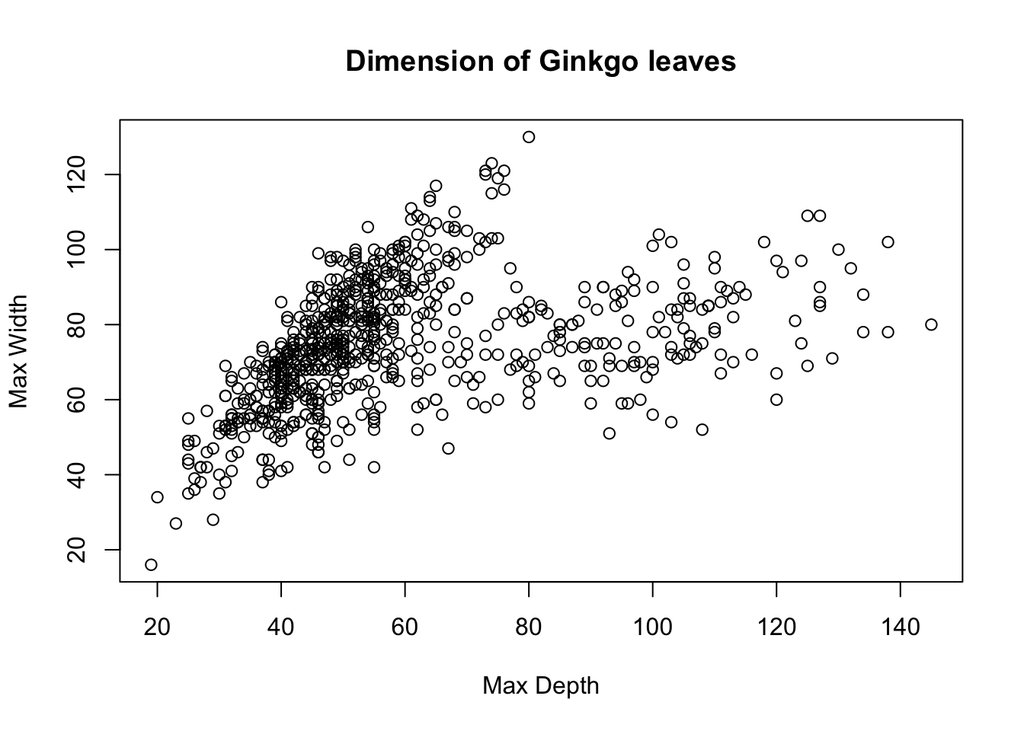

```r
plot(x = ginkgo$max_depth, y = ginkgo$max_width,
     xlab = "Max Depth", ylab = "Max Width", main = "Dimension of Ginkgo leaves")
```

Plot using all arguments:

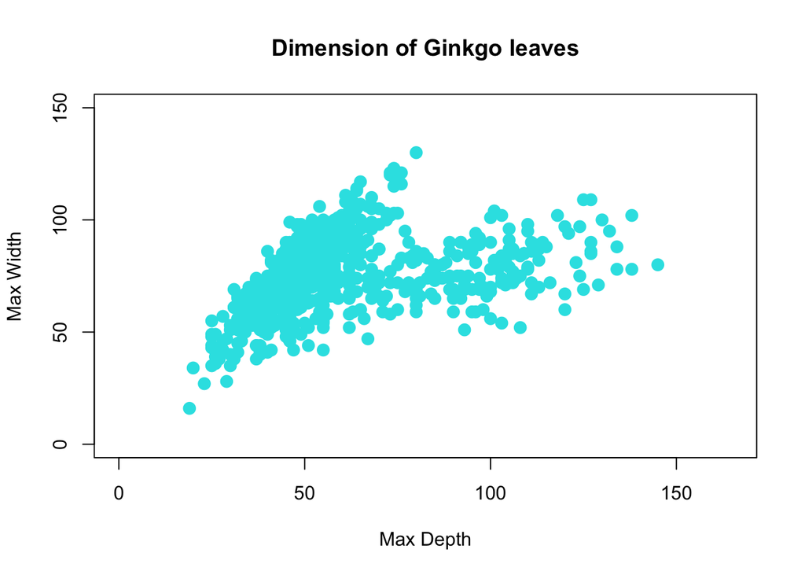

```r
plot(x = ginkgo$max_depth, y = ginkgo$max_width,
     xlab = "Max Depth", ylab = "Max Width", main = "Dimension of Ginkgo leaves", type = "p", col = "5", pch = 16, cex = 1.5, xlim = c(0, max(ginkgo$max_depth)+20), ylim = c(0, max(ginkgo$max_width)+20))
```

`plot()` required arguments:

- `col =` In R, the color black is denoted by `col = 1` in most plotting functions, red is denoted by `col = 2` , and green is denoted by `col = 3` . So if you’re plotting multiple groups of things, it’s natural to plot them using colors **1, 2, and 3**
- pch = The default R plot pch symbol is 1, which is an empty circle. You can change this to pch = 19 (solid circle) or to pch = 21 (filled circle). To change the color and the size of points, use the following arguments: col : color (hexadecimal color code or color name)
- cex = number indicating the amount by which plotting text and symbols should be scaled relative to the default. 1=default, 1.5 is 50% larger, 0.5 is 50% smaller, etc
- main = used to create a title ○ Example: `main = “Title of Graph”`
- xlab = used to label the x axis
- example: `xlab = “This is my x title”`
- ylab = used to label the y axis
- xlim = used to set limits of the x axis. Ex: `c(0, max(ginkgo$max_depth)+20)`
- ylim = used to set limits of the y axis

### Histogram

`(hist())` is used to create a histogram of data frame.

example of *penguin flipper lengths* histogram

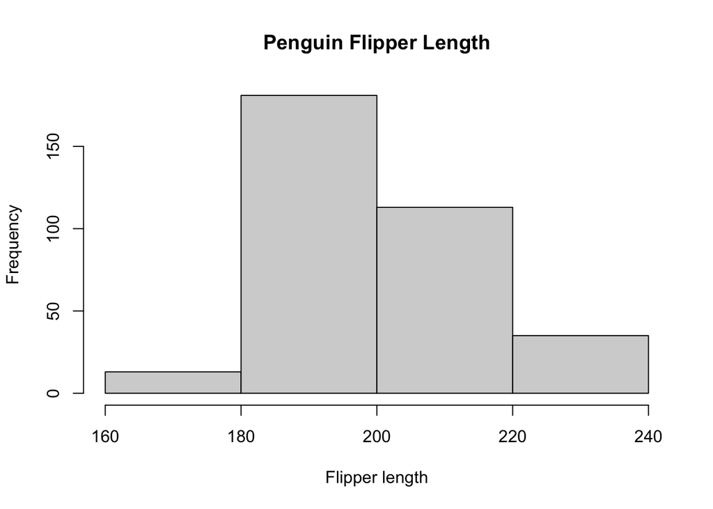

```r
hist(penguins$flipper_length_mm, xlab = "Flipper length", main = "Penguin Flipper Length", breaks = 4)
```

**Required arguments**

**breaks** shows the breaks, which are the cutoff points for the bins. It shows the counts, intensity/density for each bin ( *same thing but two different names for R version compatibility* ), the midpoints of each bin, and then the name of the variable, whether the bins are equidistant, and the class of the object.

### Boxplot

- Two examples using the ginkgo data:

a simple boxplot of ginkgo petiole lengths

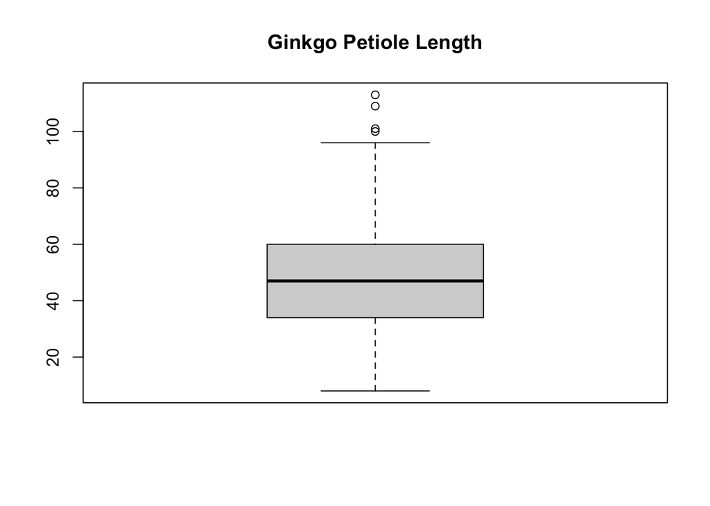

```r
boxplot(ginkgo$petiole_length, main = "Ginkgo Petiole Length")
```

conditional boxplot of one of the continuous variables conditioned on the `seeds_present` column

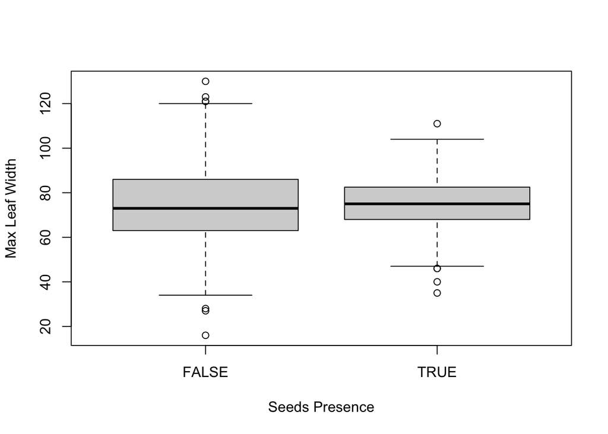

```r
boxplot(data = ginkgo, max_width ~ seeds_present, "Max width by Seeds present", xlab = "Seeds Presence", ylab = "Max Leaf Width")
```

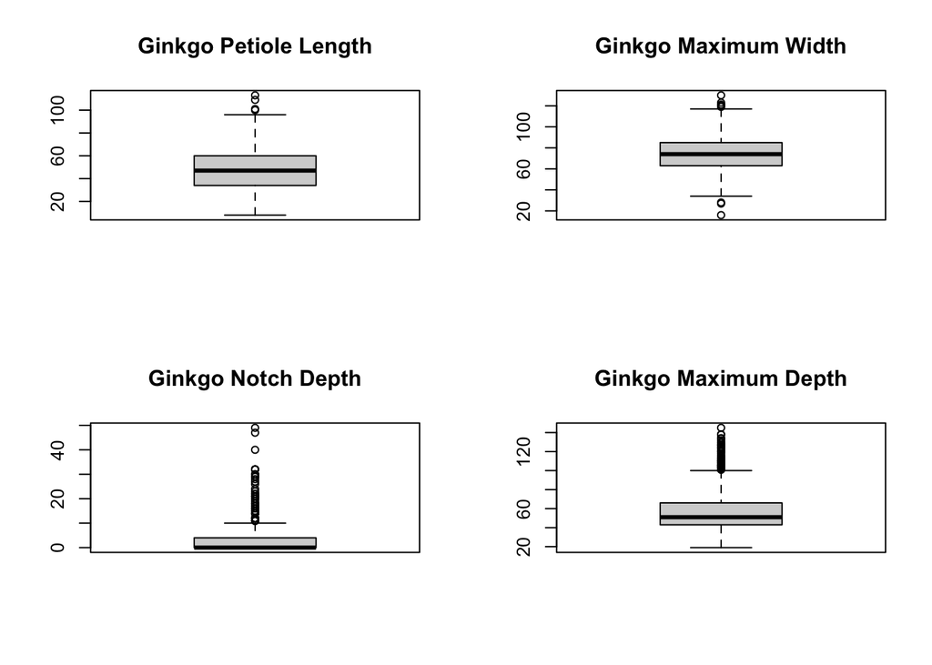

```r
par(mfrow = c(2,2))
boxplot(ginkgo$petiole_length, main = "Ginkgo Petiole Length")
boxplot(ginkgo$max_width, main = "Ginkgo Maximum Width")
boxplot(ginkgo$notch_depth, main = "Ginkgo Notch Depth")
boxplot(ginkgo$max_depth, main = "Ginkgo Maximum Depth")
```

## Distribution Functions:

`dnorm`, `pnorm`, `qnorm` and `rnorm` are used to pull numbers from a normal distribution.

`dnorm` calculates the probability density (or mass) of a single event based on a normally distributed population, for example the probability of observing a sample mean 4.3cm for penguin flipper length.

`pnorm` can be used to calculate the probability of observing values on above or below a critical value when calculating a confidence interval.

`qnorm()` calculates the quantile for a given value in a normal distribution. The mean and standard deviation of the distribution must be provided.

`dbinom()` calculates the probability of an exact given value occurring in a binomial distribution. The size and probability must be provided.

### `dnorm()`

example: It finds the value of y (height of the curve) for a given value of x. The mean and standard deviation of the distribution must be provided.

```r
dnorm(1.5, mean = 0, sd = 1)
```

```
## [1] 0.1295176
```

### `pnorm()`

example: It finds the probability of the given value OR LESS occurring. The mean and standard deviation of the distribution must be provided.

```r
pnorm(1.5, mean = 0, sd = 1)
```

```
## [1] 0.9331928
```

To find the probability of the given value OR MORE, use the “lower.tail = FALSE” option.

```r
pnorm(1.5, mean = 0, sd = 1, lower.tail = FALSE)
```

```
## [1] 0.0668072
```

### `qnorm()`

example: The mean and standard deviation of the distribution must be provided.

```r
qnorm(0.85,mean=70,sd=3)
```

```
## [1] 73.1093
```

### `_binom`

The _binom functions work to generate the binomial distribution with the density, distribution, and quantile functions as well as with random number generation using parameters size and prob. This is conventionally interpreted as the number of ‘successes’ in size trials.

- **dbinom()**: the probability mass function - dbinom () calculates the probability of an exact given value occurring in a binomial distribution. The size and probability must be provided.

```r
dbinom(x = 1:10, size = 10, prob = 0.2)
```

```
##  [1] 0.2684354560 0.3019898880 0.2013265920 0.0880803840 0.0264241152
##  [6] 0.0055050240 0.0007864320 0.0000737280 0.0000040960 0.0000001024
```

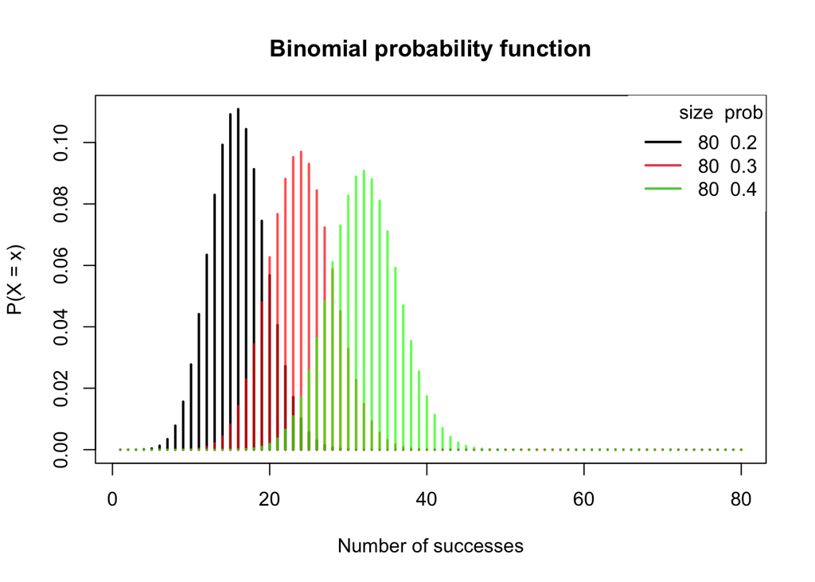

```r
# Grid of X-axis values
x <- 1:80

# size = 80, prob = 0.2
plot(dbinom(x, size = 80, prob = 0.2), type = "h", lwd = 2,
     main = "Binomial probability function",
     ylab = "P(X = x)", xlab = "Number of successes")

# size = 80, prob = 0.3
lines(dbinom(x, size = 80, prob = 0.3), type = "h",
      lwd = 2, col = rgb(1,0,0, 0.7))

# size = 80, prob = 0.4
lines(dbinom(x, size = 80, prob = 0.4), type = "h",
      lwd = 2, col = rgb(0, 1, 0, 0.7))

# Add a legend
legend("topright", legend = c("80  0.2", "80  0.3", "80  0.4"),
       title = "size  prob", title.adj = 0.95,
       lty = 1, col = 1:3, lwd = 2, box.lty = 0)
```

- **pbinom()**: the cumulative mass function In order to calculate the probability of a variable XX following a binomial distribution taking values lower than or equal to xx you can use the pbinom function, which arguments are described below:

```
pbinom(q,                 # Quantile or vector of quantiles
       size,              # Number of trials (n > = 0)
       prob,              # The probability of success on each trial
       lower.tail = TRUE, # If TRUE, probabilities are P(X <= x), or P(X > x) otherwise
       log.p = FALSE)     # If TRUE, probabilities are given as log
```

```r
pbinom(6, size = 20, prob = 0.4) # 0.2500107 or 25%
```

```
## [1] 0.2500107
```

```r
1 - pbinom(6, size = 20, prob = 0.4, lower.tail = FALSE) # Equivalent
```

```
## [1] 0.2500107
```

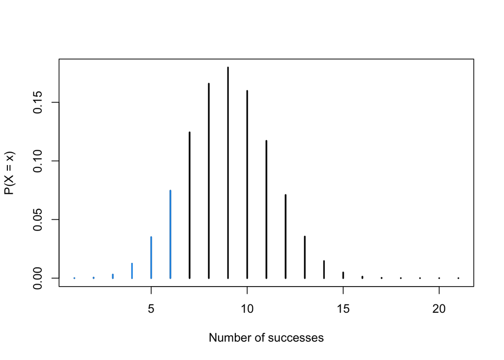

```r
binom_sum(size = 20, prob = 0.4, ub = 6, lwd = 2,
          ylab = "P(X = x)", xlab = "Number of successes")
```

example code:

```r
pbinom(3, size = 10, prob = 0.3)
```

```
## [1] 0.6496107
```

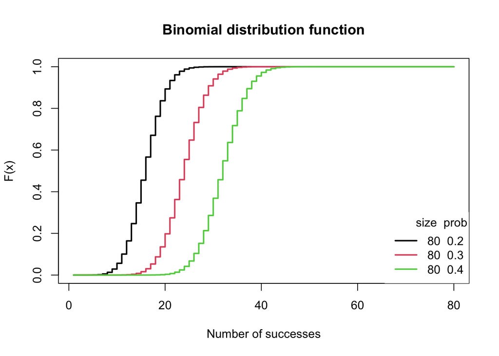

```r
# Grid of X-axis values
x <- 1:80

# size = 80, prob = 0.2
plot(pbinom(x, size = 80, prob = 0.2), type = "s", lwd = 2,
     main = "Binomial distribution function",
     xlab = "Number of successes", ylab = "F(x)")

# size = 80, prob = 0.3
lines(pbinom(x, size = 80, prob = 0.3), type = "s",
      lwd = 2, col = 2)

# size = 80, prob = 0.4
lines(pbinom(x, size = 80, prob = 0.4), type = "s",
      lwd = 2, col = 3)

# Add a legend
legend("bottomright", legend = c("80  0.2", "80  0.3", "80  0.4"),
       title = "size  prob", title.adj = 0.95,
       lty = 1, col = 1:3, lwd = 2, box.lty = 0)
```

- **qbinom()**: the quantile function The binomial quantile function can be plotted in R for a set of probabilities, a number of trials and a probability of success with the following code:

[figure not shown]

| **FINISH PART 1** |
| --- |

```r
# Grid of X-axis values
x <- 1:80

# size = 80, prob = 0.2
plot(qbinom(seq(0, 1, 0.001), size = 80, prob = 0.2),
     main = "Binomial quantile function",
     ylab = "Q(p)", xlab = "p",
     type = "s", col = 3, xaxt = "n")
axis(1, labels = seq(0, 1, 0.1), at = 0:10 * 100)

# size = 80, prob = 0.3
lines(qbinom(seq(0, 1, 0.001), size = 80, prob = 0.3), type = "s", col = 2)

# size = 80, prob = 0.4
lines(qbinom(seq(0, 1, 0.001), size = 80, prob = 0.4), type = "s", col = 1)

# Add a legend
legend("topleft", legend = c("80  0.2", "80  0.3", "80  0.4"),
       title = "size  prob", title.adj = 0.95,
       lty = 1, col = 1:3, lwd = 2, box.lty = 0)
```